# **clustering**

andrés castro araújo

2020-05-13

Most of this notebook comes straight from Susan Holmes and Wolgang Huber’s [**Modern Statistics for Modern Biology**](http://web.stanford.edu/class/bios221/book/index.html) (2018, chap. 5).

It’s about methods for finding meaningful clusters (or groups) in data.

*Note. These clustering methods will always find groups in data, even if there are none. Thus, we also focus on cluster **validation***

*There are over 100 packages that provide clustering tools in [CRAN](https://CRAN.R-project.org/view=Cluster).*

## similarity

Clustering results will depend on the *features* we choose and how they are combined into a single *distance metric*. What exactly do we mean by “similar”?

Here’s a selection of choices:

- **Euclidean**. The Euclidean distance between two points $A = (a_1, \dots, a_p)$ and $B = (b_1, \dots, b_p)$ in a $p$-dimensional space (for the $p$ features) is the square root of the sum of squares of the differences in all $p$ coordinate directions.

  $$\textsf{dist}(A, B) = \sqrt{\sum_{i=1}^p (a_i - b_i)^2}$$

  ```r
  dist_euclidean <- function(a, b) sqrt(sum((a-b)^2))

  p <- 20
  a <- runif(p, min = 1, max = 10)
  b <- runif(p, min = 1, max = 10)

  dist_euclidean(a, b)
  ```

  ```
  [1] 16.51111
  ```

- **Manhattan**. It takes the sum of the absolute differences in all coordinates. It’s also known as the City Block, Taxicab or $L_1$ distance.

  $$\textsf{dist}(A, B) = \sum_{i=1}^p | a_i - b_i |$$

  ```r
  dist_manhattan <- function(a, b) sum(abs(a - b))

  dist_manhattan(a, b)
  ```

  ```
  [1] 60.90137
  ```

- **Maximum**. The maximum of the absolute differences between coordinates is also called the $L_\infty$ distance.

  $$\textsf{dist}(A, B) = \max_i |a_i - b_i |$$

  ```r
  dist_maximum <- function(a, b) max(abs(a - b))

  dist_maximum(a, b)
  ```

  ```
  [1] 6.968363
  ```

- **Weighted Euclidean distance**. A generalization of the ordinary Euclidean distance, it gives different weights to different directions in feature space.

  A common example is the $\chi^2$ (chi-squared) distance, which is used to compare rows in contingency tables (the weight of each feature is the inverse of the expected value).

  Another common example is the **Mahalanobis** distance, “takes into account the fact that different features may have a different dynamic range, and that some features may be positively or negatively correlated with each other”. The weights here are derived from the covariance matrix of the features.
- **Jaccard Distance**. Occurrence of traits or features can be translated into presence and absence (and encoded as 1’s and 0’s). In such situations, *co-occurence is often more informative than co-absence.* For two vectors $A$ and $B$, we call $f_{11}$ the number of times a feature occurs in both vectors, $f_{00}$ the number of times a feature is co-absent, $f_{10}$ the number of times it occurs in $A$ but not $B$ (and vice versa with $f_{01}$). The Jaccard index is just:

  $$J(A, B) = \frac{f_{11}}{f_{10} + f_{01} + f_{11}}$$

  Essentially, we discard $f_{00}$. The Jaccard distance is then as follows:

  $$\textsf{dist}(A, B) = 1 - J(A, B) = \frac{f_{10} + f_{01}}{f_{10} + f_{01} + f_{11}}$$

  ```r
  x <- sample(c(0, 1), p, replace = TRUE)
  y <- sample(c(0, 1), p, replace = TRUE)
  str(list(x, y))
  ```

  ```
  List of 2
   $ : num [1:20] 1 1 1 1 0 1 1 0 0 1 ...
   $ : num [1:20] 0 1 1 1 1 0 1 0 1 0 ...
  ```

  ```r
  dist_jaccard <- function(a, b) {

    stopifnot(all(a == 1 | a == 0), all(b == 1 | b == 0))

    f11 <- sum(a == 1 & b == 1)
    f10 <- sum(a == 1 & b == 0)
    f01 <- sum(a == 0 & b == 1)

    (f10 + f01) / (f10 + f01 + f11)

  }


  dist_jaccard(x, y)
  ```

  ```
  [1] 0.75
  ```

  ```r
  dist_jaccard(x, x)
  ```

  ```
  [1] 0
  ```

- **Edit, Hamming**. This distance is the simplest way to compare character sequences. It simply counts the number of character substitutions between two character strings. This distance only applies to same length sequences. If you also allow for deletions and insertions, you end up with something called **Levenshtein distance**.

  The algorithm for calculating the minimum edit distance (i.e. minimum edit operations like *insertion*, *deletion*, and *substitution*) is implemented by giving each operation a “cost” and using *dynamic programming*. Here’s an R implementation of the algorithm. For more information on this implementation see Jurafsky & Martin (2008).

  ```r
  dist_levenshtein <- function(a, b) {

    a <- unlist(strsplit(a, split = ""))
    b <- unlist(strsplit(b, split = ""))

    D <- array(NA, dim = c(length(a) + 1, length(b) + 1))
    D[1, ] <- 0:length(b)
    D[, 1] <- 0:length(a)

    sub_cost <- function(x, y) if (x == y) 0 else 2

    for (i in seq_along(a)) {
      for (j in seq_along(b)) {
        cost <- c(D[i, j + 1] + 1, D[i + 1, j] + 1, D[i, j] + sub_cost(a[i], b[j]))
        D[i + 1, j + 1] <- min(cost)
      }
    }
    return(D[length(a) + 1, length(b) + 1])
  }
  ```

  ```r
  dist_levenshtein("andres", "andrea") # substitution cost = 2
  ```

  ```
  [1] 2
  ```

  ```r
  dist_levenshtein("intention", "purpose")
  ```

  ```
  [1] 14
  ```

We can also compare the distances between complex objects using other metrics that we won’t cover here (e.g. shortest paths between nodes in graph).

> Distances and dissimilarities are also used to compare images, sounds, maps and documents. A distance can usefully encompass domain knowledge and, if carefully chosen, can lead to the solution of many hard problems involving heterogeneous data.

The `dist()` function in R computes six distance metrics (euclidean, maximum, manhattan, canberra, binary, and minkowski) and outputs a vector of values sufficient to reconstruct the complete distance matrix.

```r
c <- a + rnorm(p)
dist(rbind(a, b, c), "euclidean")
```

```
          a         b
b 16.511113
c  4.017134 17.126538
```

```r
dist(rbind(a, b, c), "manhattan")
```

```
         a        b
b 60.90137
c 15.15857 62.64006
```

## partitioning methods

The EM algorithm and other forms of *parametric mixture modeling* will not work well in high-dimensional settings (see [“curse of dimensionality”](https://en.wikipedia.org/wiki/Curse_of_dimensionality)). This is why instead we use **partitioning** or **iterative relocation methods**.

For example, the **PAM** (partitioning around medoids) method works as follows:

1. Start from a matrix of $p$ features measured on a set of $n$ observations.
2. Randomly pick $k$ distinct cluster centers out of the $n$ observations (“seeds”).

   Recall that, besides the distance measure, *the main choice to be made is the number of clusters $k$.*
3. Assign each of the remaining observations to the group whose center is closest.
4. For each group, *choose a new center from the observations in the group, such that the sum of the distances of group members to the center is minimal*. This is called *the medoid*.
5. Repeat steps 3 and 4 until the groups stabilize.

Note that different initial seeds will be picked in Step 2 each time the algorithm is run. This can lead to different final results. A popular implementation is the `cluster::pam()` function.

The **$k$-means method** is a slight variation of this method: the medoids are replaced by the arithmetic means (centers of gravity) of the clusters. The `stats::kmeans()` function comes with every installation of R.

> These so-called $k$-methods are the most common off-the-shelf methods for clustering; they work particularly well when the clusters are of comparable size and convex (blob-shaped). On the other hand, if the true clusters are very different in size, the larger ones will tend to be broken up; the same is true for groups that have pronounced non-spherical or non-elliptic shapes.

At this point, this sounds very similar to what the EM-algorithm does. This is one of the main difference between them:

> In the EM algorithm, each point participates in the computation of the mean of all the groups through a probabilistic weight assigned to it. In the $k$-means method, the points are either attributed to a cluster or not, so each point participates only, and entirely, in the computation of the center of one cluster.

This is my implementation of the $k$-means clustering algorithm (`stats::kmeans()` is much faster, but the code is less concise):

```r
k_means_clustering <- function(X, k, max_iter = 300) {

  X <- as.matrix(X)
  clusters <- sample(1:k, nrow(X), replace = TRUE) ## initial random assignment

  # This function calculates rowwise euclidean distance
  dist_to_k <- function(k) apply(X, MARGIN = 1, function(x) sqrt(sum((x - centroids[k, ])^2)))

  iter <- 0

  repeat {

    centroids <- map(1:k, ~ X[clusters == .x, ]) %>%
      map(colMeans) %>%
      do.call(rbind, args = .)

    clusters_next <- map(1:k, dist_to_k) %>%
      do.call(cbind, args = .) %>%
      apply(MARGIN = 1, function(x) which(x == min(x))) ## rowise cluster assignment

    iter <- iter + 1

    if (identical(clusters_next, clusters) | iter >= max_iter) break

    clusters <- clusters_next

  }

  rownames(centroids) <- 1:k
  return(list(clusters = unname(clusters), centroids = centroids, iterations = iter))

}

k_means_clustering(datasets::faithful, k = 2)
```

```
$clusters
  [1] 1 2 1 2 1 2 1 1 2 1 2 1 1 2 1 2 2 1 2 1 2 2 1 1 1 1 2 1 1 1 1 1 2 1 1 2 2
 [38] 1 2 1 1 2 1 2 1 1 2 2 1 2 1 1 2 1 2 1 1 2 1 1 2 1 2 1 2 1 1 1 2 1 1 2 1 1
 [75] 2 1 2 1 1 1 1 1 1 2 1 1 1 1 2 1 2 1 2 1 2 1 1 1 2 1 2 1 2 1 1 2 1 2 1 1 1
[112] 2 1 1 2 1 2 1 2 1 2 1 1 2 1 1 2 1 2 1 2 1 2 1 2 1 2 1 2 1 1 2 1 1 1 2 1 2
[149] 1 2 1 1 2 1 1 1 1 1 2 1 2 1 2 1 2 1 2 1 2 1 2 2 1 1 1 1 1 2 1 1 2 1 1 1 2
[186] 1 1 2 1 2 1 2 1 1 1 1 1 1 2 1 2 1 1 2 1 2 1 1 2 1 1 1 2 1 2 1 2 1 2 1 2 1
[223] 2 1 1 1 1 1 1 1 1 2 1 2 1 2 2 1 1 2 1 2 1 2 1 1 2 1 2 1 2 1 1 1 1 1 1 1 2
[260] 1 1 1 2 1 2 2 1 1 2 1 2 1

$centroids
  eruptions  waiting
1   4.29793 80.28488
2   2.09433 54.75000

$iterations
[1] 4
```

We can obtain **tight clusters** by repeating this process many times (using different initial values or resampled datasets) and identifying groups of observations that are *almost always* grouped together. Paying attention to these tight clusters will facilitate in choosing the right number of $k$ clusters.

### density-based clustering

As mentioned earlier, $k$-methods tend to work well when the hidden groups are convex (i.e. blob-shaped) and of comparable size. If the data isn’t structured like this, we have to use other partitioning methods such as **density-based clustering**. This method looks for regions of high density that are separated by sparser regions.

A common implemenation of such a method is available in the **`dbscan`** package.

*An example*

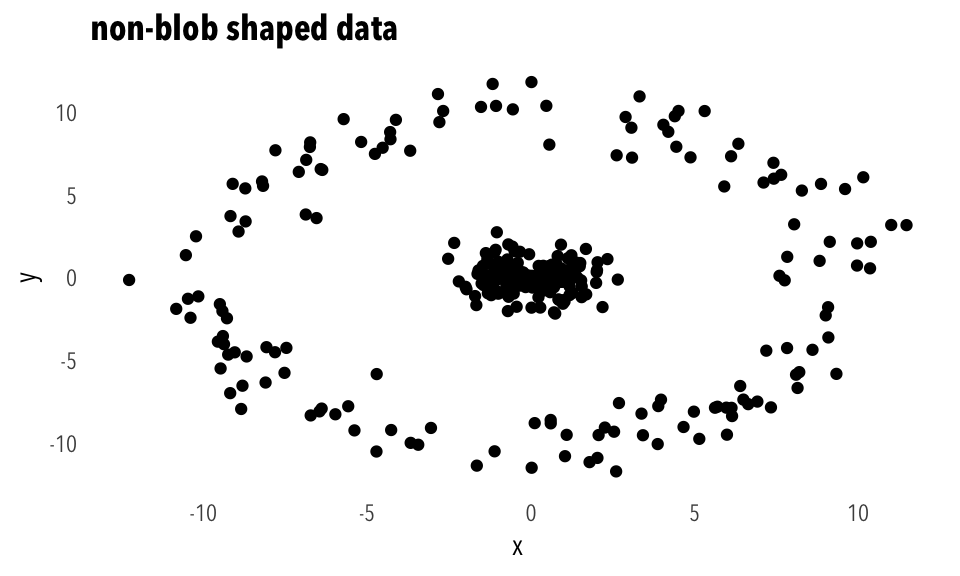

```r
n <- 150
theta <- runif(n, 0, 2 * pi)
r <- rnorm(n, 10)
non_blob_data <- bind_rows(
  tibble(x = rnorm(n), y = rnorm(n)),
  tibble(x = r*cos(theta), y = r*sin(theta))
)

ggplot(non_blob_data, aes(x, y)) + geom_point() + labs(title = "non-blob shaped data")
```

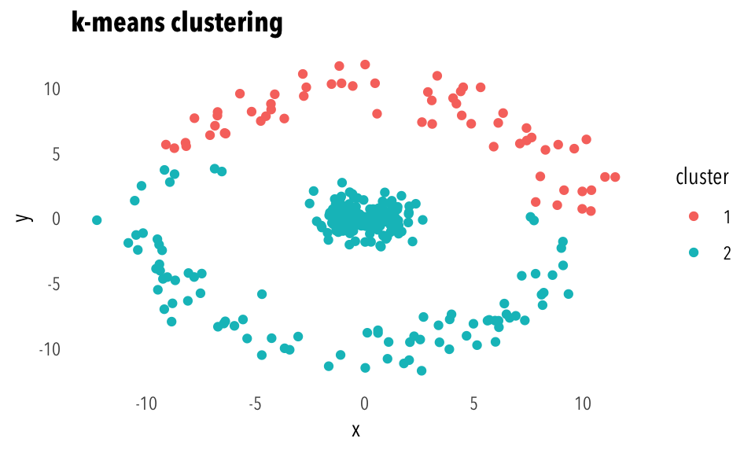

```r
km_output <- kmeans(non_blob_data, centers = 2)
ggplot(non_blob_data, aes(x, y)) +
  geom_point(aes(color = factor(km_output$cluster))) +
  labs(title = "k-means clustering", color = "cluster")
```

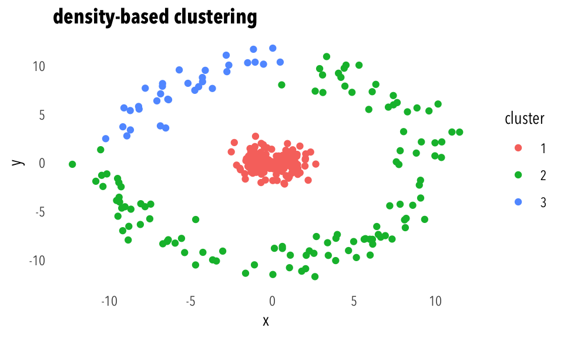

```r
library(dbscan)

db_output <- dbscan(non_blob_data, eps = 2.5)
ggplot(non_blob_data, aes(x, y)) +
  geom_point(aes(color = factor(db_output$cluster))) +
  labs(title = "density-based clustering", color = "cluster")
```

The **dbscan method** will cluster points in accordance to the *density-connectedness criterion.* It looks at small neighborhood spheres of radius $\epsilon$ to see if points are connected.

We say that a point $a$ is **density-reachable** from $b$ if there’s a sequence of points $a_1, ..., a_n$ such that $a_{i + 1}$ and $a_i$ are within $\epsilon$ distance from each other, and $a_n = b$. Thus, a cluster is just a subset of mutually density-connected points.

*Note. The size of $\epsilon$ increases with the number of $p$ dimensions due to the “curse of dimensionality”*.

## agglomerative methods

Hierarchical clustering is a bottom-up approach. Each observation starts as a cluster of its own, and then gets sequentially combined into larger clusters.

This nested (or hierarchical) organization is usually portrayed with **dendrograms**. The following figure shows three representations of the *same* hierarchical clustering tree. Note that vertical distances are informative but that horizontal distances are essentially meaningless.

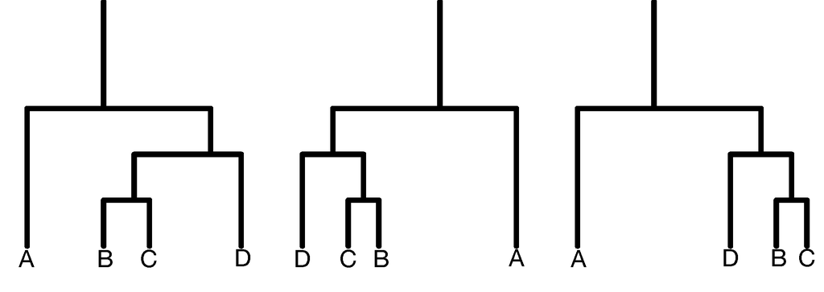

> When creating a hierarchical clustering by aggregation, we will need more than just the distances between all pairs of individual objects: we also need a way to calculate distances between the aggregates. There are different choices of how to define them, based on the object-object distances, and each choice results in a different type of hierarchical clustering.

In other words, we need to choose how to calculate the distance *between* newly formed clusters.

- **Single linkage (or minimal jump)**. This method computes the distance between clusters as the *smallest* distance between any two points in the two clusters.

$$\textsf{dist}(C_1, C_2) = \min_{i \in C_1 \ , \ j \in C_2} \textsf{dist}(i, j)$$

- **Complete linkage (or maximal jump)**. This method computes the distance between clusters as the *largest* distance between any two points in the two clusters.

$$\textsf{dist}(C_1, C_2) = \max_{i \in C_1 \ , \ j \in C_2} \textsf{dist}(i, j)$$

- **Average linkage**. This method computes the distance between clusters as the *average* distance between any two points in the two clusters.

$$\textsf{dist}(C_1, C_2) = \frac{1}{|C_1||C_2|}\sum_{i \in C_1} \sum_{j \in C_2} \textsf{dist}(i, j)$$

- **Centroid linkage**. This method computes the distance between clusters as the distance between the centroids of each cluster.
- **Ward’s method** minimizes the variance *within* clusters and maximizes variance *between* clusters.

Here I show how the methods produce different groupings for two different types of data.

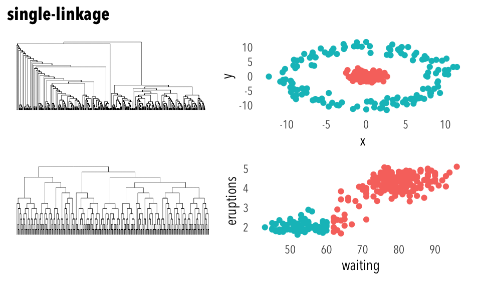

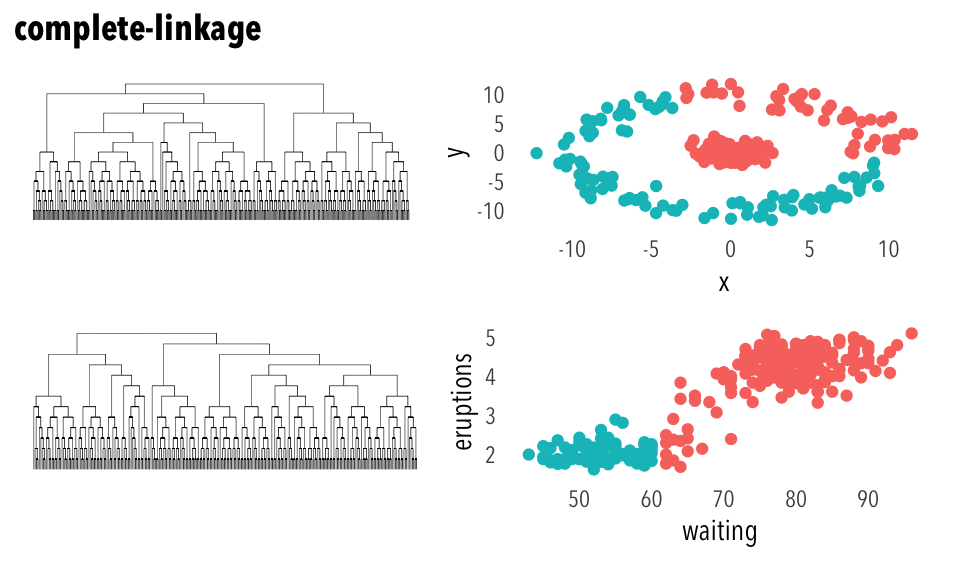

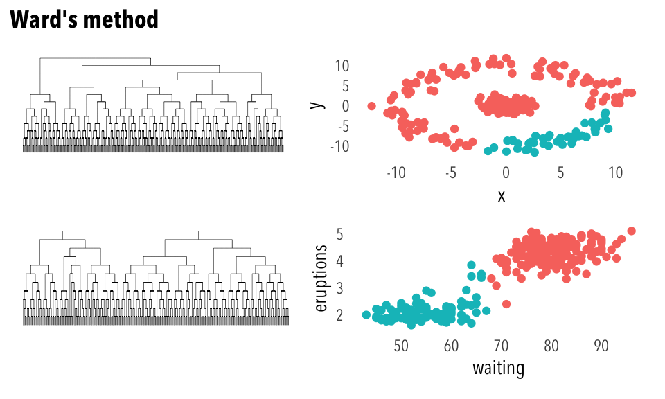

*Note. When we think that the clusters are about the same size, using average linkage or Ward’s method of minimizing the within class variance produces best results. The single-linkage method produces results that are more inline with the previously shown dbscan method.*

## validation

All of these clustering methods will always find groups in data, even if there are none.

A usual criterion is the *within-groups sum of squared distances (WSS)*. We ask: *to ask to what extent does it maximize the between group differences while keeping the within-group distances small?*

$$\text{WSS}_k = \sum_{\ell=1}^k \sum_{x_i \in C_l} \textsf{dist}(x_i, \bar x_\ell)^2$$

Here, $k$ is the number of clusters; $C_\ell$ is the set of objects in the $\ell$-th cluster; and $\bar x_\ell$ is the center of mass (the average point) in the $\ell$-th cluster.

> Stated as it is, the WSS is however not a sufficient criterion: the smallest value of WSS would simply be obtained by making each point its own cluster. The WSS is a useful building block, but we need more sophisticated ideas than just looking at this number alone.

One common idea is to look at $\text{WSS}_k$ as a function of $k$ and look for a pronounced decrease, which we interpret as a sort of sweet spot for $k$.

For example:

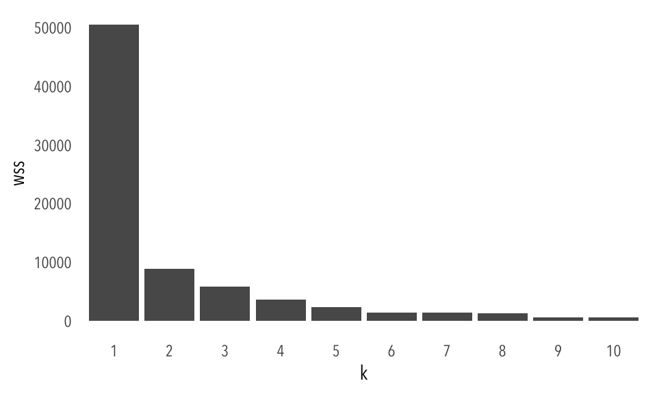

```r
wss <- function(X, k) {
  kmeans(X, centers = k)$tot.withinss
}

wss_values <- map_dbl(1:10, wss, X = datasets::faithful)

tibble(k = factor(1:10), wss = wss_values) %>%
  ggplot(aes(k, wss)) +
  geom_col()
```

### bootstrap validation

Another approach involves taking bootstrap samples of the original data and comparing the different clusterings we get each time. Note that this is not as straightfoward as it may seem because of the “label switching” problem.

There are many ways of doing this, and I’ll come back here when I figure out the best approach.

## references

Holmes, Susan, and Wolfgang Huber. 2018. *Modern Statistics for Modern Biology*. Cambridge University Press.

Jurafsky, Dan, and James H Martin. 2008. *Speech & Language Processing*. Pearson.